Universidad El Bosque

Series de Tiempo

Capítulo 5 · dos clases de 90–100 min (estimado)

# Modelos SARIMA

SARIMAestacionalidadsatélitesD antes que dairlineAICc entre distintos DcalendarioFourierSTLorigen móvil

**Javier Mauricio Sierra**

Universidad El Bosque

Series de Tiempo

Capítulo 5 · Modelos SARIMA

Clase 1 · Módulo 1 · La firma de la estacionalidad

Módulo 2 · Notación SARIMA y polinomio multiplicativo

Módulo 3 · Diferenciación estacional: cuántas y en qué orden

Módulo 4 · Identificar los órdenes estacionales

Módulo 5 · El modelo airline

Clase 2 · Módulo 6 · Estimar, comparar y diagnosticar

Módulo 7 · Caso completo: log(AirPassengers)

Módulo 8 · Segundo caso y contraejemplo

Módulo 9 · Regresores de calendario y SARIMAX

Módulo 10 · Cuando \(m\) es grande: Fourier y STL

Módulo 11 · Panorama comparativo y cierre

Hoja de ruta

## Lo que vamos a construir hoy

Objetivo de la sesión

Reconocer la estacionalidad donde de verdad se ve, escribirla como un polinomio que multiplica, decidir D antes que d y recorrer el ciclo completo con el modelo airline, hasta compararlo de forma honesta con las alternativas.

SARIMAestacionalidadsatélitesD antes que dairlineAICc entre distintos DcalendarioFourierSTLorigen móvil

2 / 84

Modelos SARIMA

## Cada afirmación es un dato, una definición, una interpretación o una opinión

Cada afirmación lleva su etiqueta y cada cifra, su fuente: así se distingue lo que se midió de lo que se interpreta.

| Etiqueta | Qué es |
| --- | --- |
| `Dato` | Una cifra calculada sobre una serie concreta; lleva fuente y se contrastó en R |
| `Definición` | Una verdad matemática o una convención: no depende de la serie |
| `Interpretación` | La lectura que el capítulo hace de los datos: se puede discutir |
| `Opinión` | Una recomendación o regla práctica: se defiende, no se demuestra |

[SIN VERIFICAR] marca lo que no se pudo contrastar con una fuente: no es un dato confirmado.

Fuentes: **J** = `cap5_sarima.json` · **J4** = `cap4_arima.json` · **J3** = `cap3_arma.json` · **R** = recálculo en R 4.6 · **PY** = statsmodels · **C** = capítulo · **D** = documentación de R3 / 84

Universidad El Bosque

Series de Tiempo

Capítulo 5 · Modelos SARIMA

Clase 1 · Módulo 1 · La firma de la estacionalidad

Módulo 2 · Notación SARIMA y polinomio multiplicativo

Módulo 3 · Diferenciación estacional: cuántas y en qué orden

Módulo 4 · Identificar los órdenes estacionales

Módulo 5 · El modelo airline

Clase 2 · Módulo 6 · Estimar, comparar y diagnosticar

Módulo 7 · Caso completo: log(AirPassengers)

Módulo 8 · Segundo caso y contraejemplo

Módulo 9 · Regresores de calendario y SARIMAX

Módulo 10 · Cuando \(m\) es grande: Fourier y STL

Módulo 11 · Panorama comparativo y cierre

Parte 1 de 11

01

## Clase 1 · Módulo 1 · La firma de la estacionalidad

El capítulo 4 terminó con un fracaso deliberado: toda la estructura que el mejor ARIMA no estacional no capturaba estaba en un solo sitio.

Leer en el material: La firma de la estacionalidad

4 / 84

Clase 1 · Módulo 1 · La firma de la estacionalidad

## El capítulo 4 dejó toda la estructura sobrante en los múltiplos de 12

- `Dato` El mejor ARIMA no estacional, un ARIMA(0,1,5), deja en sus residuales \(\hat\rho_{12}=0.7245\) y \(\hat\rho_{24}=0.6727\), con banda \(\pm0.163\); Ljung–Box(24): \(Q=222.4\)
- `Dato` El *airline* (SARIMA(0,1,1)(0,1,1)\(_{12}\), Módulo 5), con **dos** parámetros, deja \(\hat\rho_{12}=-0.0515\) y pasa Ljung–Box(24) con \(p=0.233\)
- `Interpretación` Cinco términos MA no bastan porque lo que falta no está en los primeros rezagos: está en 12, 24, 36

Contexto: `AirPassengers` en logaritmos, mensual, 1949–1960 (\(n=144\)). Fuente: J4 `puente_estacional` · J `airline.diagnostico` · R

Capítulo 5 · Modelos SARIMASeries de Tiempo · UnBosque5 / 84

Clase 1 · Módulo 1 · La firma de la estacionalidad

## Cuatro series conducen el capítulo, y la cuarta es un contraejemplo

| Serie | De dónde sale | Qué ilustra |
| --- | --- | --- |
| **log(AirPassengers)** · pasajeros aéreos, 1949–1960 (*n* = 144) | `AirPassengers` de R; Box, Jenkins y Reinsel (1994) | El ciclo completo |
| **USAccDeaths** · muertes accidentales en EE. UU., 1973–1978 (*n* = 72) | `USAccDeaths` de R; Brockwell y Davis (1991) | Pruebas que engañan |
| **co2** · CO₂ en Mauna Loa, 1959–1997 (*n* = 468) | `co2` de R; Keeling y Whorf (Scripps) | Los ejercicios |
| **TRM** · COP/USD, ene. 2015–jun. 2026 (*n* = 138) | Superintendencia Financiera (SFC), vía datos.gov.co [SIN VERIFICAR] | Mensual **sin** estación |

Todas mensuales. «Qué ilustra» es `Interpretación` del capítulo. TRM: copia congelada, no cotejada con datos.gov.co. Fuente: R · D `?AirPassengers`, `?USAccDeaths`, `?co2`

Capítulo 5 · Modelos SARIMASeries de Tiempo · UnBosque6 / 84

Clase 1 · Módulo 1 · La firma de la estacionalidad

## La estacionalidad tiene un periodo fijado por el calendario; el ciclo, no

Estacionalidad de periodo \(m\)

El patrón se repite cada \(m\) observaciones y \(m\) lo fija el **calendario**: \(m=12\) mensual, \(4\) trimestral, \(7\) diario con patrón semanal, \(52\) semanal.

- `Definición` El **ciclo** tiene duración variable y desconocida: los 11.22 años de las manchas solares del capítulo 3
- `Interpretación` Si \(m\) es conocido, se **impone** (diferenciar cada 12, un parámetro en el rezago 12); si no, hay que estimarlo, y eso es otro problema

Fuente: C Módulo 1 · J3 `cap3_arma.json` (periodo de las manchas solares: 11.2178 años)7 / 84

Clase 1 · Módulo 1 · La firma de la estacionalidad

## Con datos mensuales la estacionalidad está en 12, 24 y 36, no en los primeros rezagos

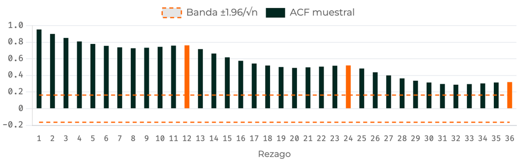

ACF de log(AirPassengers) hasta el rezago 36, con los rezagos 12, 24 y 36 resaltados y la banda ±1.96/√n (simulador del Módulo 1)

`Dato` Picos en \(\hat\rho_{12}=0.762\), \(\hat\rho_{24}=0.520\) y \(\hat\rho_{36}=0.319\), todas sobre la banda \(\pm0.163\). `Opinión` Pedir siempre **al menos \(3m\)** rezagos: con 20 o 24 se ve un pico y no se sabe si decae.

Contexto: `AirPassengers` en logaritmos, \(n=144\). Fuente: J `firma.airpassengers_log` · R

Capítulo 5 · Modelos SARIMASeries de Tiempo · UnBosque8 / 84

Clase 1 · Módulo 1 · La firma de la estacionalidad

## Cuatro filas se parecen y solo tres de esas series son estacionales

| Serie | \(\hat\rho_1\) | \(\hat\rho_{12}\) | \(\hat\rho_{24}\) | \(\hat\rho_{36}\) | Banda |
| --- | --- | --- | --- | --- | --- |
| log(AirPassengers) | 0.954 | 0.762 | 0.520 | 0.319 | 0.163 |
| USAccDeaths | 0.707 | 0.629 | 0.450 | 0.302 | 0.231 |
| co2 (Mauna Loa) | 0.991 | 0.928 | 0.855 | 0.783 | 0.091 |
| TRM en niveles | 0.964 | 0.636 | 0.490 | 0.225 | 0.167 |
| **∇TRM** | 0.088 | **−0.002** | −0.067 | 0.071 | 0.167 |

`Interpretación` Con tendencia, \(\hat\rho_k\) es grande en **todos** los rezagos, también en los múltiplos de 12. El diagnóstico se hace **después** de quitar la tendencia: solo la última fila dice algo.

Fuente: J `firma` · R (ACF recalculada sobre los datos; bandas \(1.96/\sqrt n\))9 / 84

Pregunta para la clase

## ¿Es estacional una serie con \(\hat\rho_{12}=0.636\) en niveles?

La TRM mensual, 138 meses. Banda \(\pm0.167\).

1. Sí, porque 0.636 supera con claridad la banda
2. Hace falta una diferencia estacional
3. La banda está mal calculada
4. Todavía no se puede decir

4 · Todavía no se puede decir

En niveles la tendencia infla **todos** los \(\hat\rho_k\): \(\hat\rho_1=0.964\) y \(\hat\rho_{36}=0.225\) son decaimiento lento, no un pico. Sobre ∇TRM los tres múltiplos de 12 valen −0.002, −0.067 y 0.071, todos dentro de \(\pm0.167\).

Fuente: J `firma.trm`, `trm_contraejemplo` · R · C autoevaluación, pregunta 110 / 84

Clase 1 · Módulo 1 · La firma de la estacionalidad

## Ver y medir la estacionalidad cabe en cinco líneas de R

Ver y medir

```
library(forecast)
ap <- log(AirPassengers)        # m = 12, n = 144

ggseasonplot(ap, year.labels = TRUE)
a <- Acf(ap, lag.max = 36, plot = FALSE)
round(a$acf[c(2, 13, 25, 37)], 4)   # rezagos 1, 12, 24, 36
#> [1] 0.9537 0.7619 0.5205 0.3193
round(1.96 / sqrt(length(ap)), 4)  # banda
#> [1] 0.1633
```

- `ggseasonplot()`: un trazo por año, los meses en el eje x
- `lag.max = 36`: **\(3m\)** rezagos
- `a$acf[1]` es el rezago 0: el 12 está en la posición 13

Fuente: código del Módulo 1, ejecutado en R 4.611 / 84

Universidad El Bosque

Series de Tiempo

Capítulo 5 · Modelos SARIMA

Clase 1 · Módulo 1 · La firma de la estacionalidad

Módulo 2 · Notación SARIMA y polinomio multiplicativo

Módulo 3 · Diferenciación estacional: cuántas y en qué orden

Módulo 4 · Identificar los órdenes estacionales

Módulo 5 · El modelo airline

Clase 2 · Módulo 6 · Estimar, comparar y diagnosticar

Módulo 7 · Caso completo: log(AirPassengers)

Módulo 8 · Segundo caso y contraejemplo

Módulo 9 · Regresores de calendario y SARIMAX

Módulo 10 · Cuando \(m\) es grande: Fourier y STL

Módulo 11 · Panorama comparativo y cierre

Parte 2 de 11

02

## Módulo 2 · Notación SARIMA y polinomio multiplicativo

Si la estacionalidad hace que \(y_t\) se parezca a \(y_{t-12}\) como la dinámica ordinaria lo hace parecerse a \(y_{t-1}\), basta escribir el mismo modelo dos veces y multiplicarlos.

Leer en el material: Notación SARIMA y polinomio multiplicativo

12 / 84

Módulo 2 · Notación SARIMA y polinomio multiplicativo

## Un SARIMA escribe el mismo modelo en \(B\) y en \(B^m\), y multiplica las dos copias

SARIMA(p,d,q)(P,D,Q)ₘ

$$\Phi_P(B^m)\,\phi_p(B)\,(1-B^m)^D(1-B)^d\,y_t = c + \Theta_Q(B^m)\,\theta_q(B)\,\varepsilon_t$$

- `Definición` **Mayúsculas**, estacionales (polinomios en \(B^m\)); **minúsculas**, regulares
- `Definición` Estacionariedad, invertibilidad, criterios y diagnóstico: lo de los capítulos 3 y 4, sobre el polinomio **ya multiplicado**

Fuente: C Módulo 2, definición13 / 84

Módulo 2 · Notación SARIMA y polinomio multiplicativo

## Multiplicar es preguntar dos veces: primero al mes anterior, después al año anterior

|  | Febrero | Marzo |
| --- | --- | --- |
| 2024 | 15 | 20 |
| 2025 | 10 | ? |

Ventas de una heladería **inventada**, en desvíos de su promedio

`Definición` SARIMA(1,0,0)(1,0,0)\(_{12}\) con \(\phi=0.6\) y \(\Phi=0.7\): \((1-0.6B)(1-0.7B^{12})\,y_t=\varepsilon_t\)

`Dato` **Regular**: lo que febrero no explica de marzo de 2024, \(20-0.6\cdot 15=11\)

`Dato` **Estacional**: esa sorpresa se repite al año siguiente, \(0.7\cdot 11=7.7\)

`Dato` **Pronóstico** de marzo de 2025: \(0.6\cdot 10+7.7=13.7\)

Contexto: cifras inventadas para seguir la cuenta a mano; \(\phi\) y \(\Phi\) son los del capítulo. Fuente: C Módulo 2, «Un ejemplo para seguir a mano»

Capítulo 5 · Modelos SARIMASeries de Tiempo · UnBosque14 / 84

Módulo 2 · Notación SARIMA y polinomio multiplicativo

## Multiplicar no es sumar: el rezago 13 aparece sin un parámetro propio

$$(1-\Phi B^{12})(1-\phi B) = 1-\phi B-\Phi B^{12}+\phi\Phi B^{13}$$

- `Definición` Un AR(13) con **dos** parámetros: de 2 a 11, cero; en el 13, \(+\phi\Phi\) en el polinomio (\(-\phi\Phi\) al despejar \(y_t\))
- `Dato` En la heladería: \(0.6\cdot 10+0.7\cdot 20-0.42\cdot 15=13.7\), como con las dos preguntas
- `Interpretación` El satélite, \(-0.42\cdot 15\), quita a marzo de 2024 lo que traía de febrero; **sumando** saldría 20

Fuente: C Módulo 2, derivación15 / 84

Módulo 2 · Notación SARIMA y polinomio multiplicativo

## Con \(\phi=0.6\) y \(\Phi=0.7\) brotan satélites en 11 y 13 que nadie pidió

[figure not shown]

ACF teórica: primero un SAR(1); después el AR(1)×SAR(1); por último, los satélites

`Definición` **Satélites**: barras en \(m\pm1\) que crea el producto. \(\rho_{11}=0.4230\) y \(\rho_{13}=0.4218\), cerca de \(\rho_1\rho_{12}=0.6016\times0.7011\).

`Interpretación` Cada satélite es un **camino**: subir un año y retroceder un mes lleva al rezago 13.

Contexto: procesos teóricos, no una serie; \(\phi\) y \(\Phi\) son los del capítulo. Fuente: J `teoricas` · R

Capítulo 5 · Modelos SARIMASeries de Tiempo · UnBosque16 / 84

Módulo 2 · Notación SARIMA y polinomio multiplicativo

## La varianza se pide a la serie diferenciada, y solo se factoriza si el modelo es MA puro

Solo con \(d=D=0\)

Con diferencias no hay varianza finita: los momentos son de \(w_t=\nabla^d\nabla_m^D y_t\).

$$\gamma_0=\operatorname{Var}(w_t)=\sigma^2\sum_{j\ge0}\psi_j^2$$

- `Dato` MA puro con \(q<m\), el *airline*: \(\gamma_0=\sigma^2(1+\theta^2)(1+\Theta^2)=1.5217\,\sigma^2\), 0.002087 frente a 0.002102 muestral
- `Dato` Con parte AR, \(\psi_{12}=\phi^{12}+\Phi\): con \(\phi=0.9\) y \(\Phi=0.7\), 15.406 exacta frente a 10.320 (−33.0 %)
- `Opinión` Con parte AR la varianza se **calcula**, no se multiplica

Contexto: *airline* sobre `AirPassengers` en logaritmos; AR(1)×SAR(1) teórico. Fuente: J `airline` · R `m2` · C Módulo 2

Capítulo 5 · Modelos SARIMASeries de Tiempo · UnBosque17 / 84

Pregunta para la clase

## En un SARIMA(1,0,0)(1,0,0)\(_{12}\), ¿cuáles son ciertas?

1. Toca el rezago 13 sin un parámetro propio en ese rezago
2. Tiene 2 parámetros libres
3. Su ACF teórica es cero en los rezagos 2 a 11
4. Escrito como AR no estacional, es un AR(13)

1, 2 y 4

La 3 es falsa: la parte AR regular llena los rezagos bajos (con \(\phi=0.6\) y \(\Phi=0.7\), \(\rho_2=0.364\)). Los intermedios valen cero solo si \(\phi=0\).

Fuente: C autoevaluación, pregunta 2 · J `teoricas.ar1_sar1`18 / 84

Módulo 2 · Notación SARIMA y polinomio multiplicativo

## En R el periodo va en `seasonal`, y el coeficiente de \(B^{13}\) sale del producto

Escribir un SARIMA

```
library(forecast)
ap  <- log(AirPassengers)
fit <- Arima(ap, order = c(0, 1, 1),
             seasonal = list(order = c(0, 1, 1), period = 12))
round(coef(fit), 4)
#>     ma1    sma1
#> -0.4018 -0.5569
th <- coef(fit)[["ma1"]]; Th <- coef(fit)[["sma1"]]
round(c(B1 = th, B12 = Th, B13 = th * Th), 4)
#>      B1     B12     B13
#> -0.4018 -0.5569  0.2238
```

- `Dato` El coeficiente de \(B^{13}\), **0.2238**, no se estima: es \(\theta\Theta\)
- `Interpretación` El choque de hace 13 meses llega por **dos caminos**, un año y un mes: por eso pesa \(\theta\Theta\)
- `Definición` La forma no multiplicativa necesita **13** parámetros para tocar los mismos rezagos
- Este SARIMA(0,1,1)(0,1,1)\(_{12}\) es el *airline* del Módulo 5

Fuente: código del Módulo 2, ejecutado en R 4.6 · J `airline.coeficientes`19 / 84

Universidad El Bosque

Series de Tiempo

Capítulo 5 · Modelos SARIMA

Clase 1 · Módulo 1 · La firma de la estacionalidad

Módulo 2 · Notación SARIMA y polinomio multiplicativo

Módulo 3 · Diferenciación estacional: cuántas y en qué orden

Módulo 4 · Identificar los órdenes estacionales

Módulo 5 · El modelo airline

Clase 2 · Módulo 6 · Estimar, comparar y diagnosticar

Módulo 7 · Caso completo: log(AirPassengers)

Módulo 8 · Segundo caso y contraejemplo

Módulo 9 · Regresores de calendario y SARIMAX

Módulo 10 · Cuando \(m\) es grande: Fourier y STL

Módulo 11 · Panorama comparativo y cierre

Parte 3 de 11

03

## Módulo 3 · Diferenciación estacional: cuántas y en qué orden

La diferencia estacional se aplica en un orden que da igual; se decide en un orden que no.

Leer en el material: Diferenciación estacional

20 / 84

Módulo 3 · Diferenciación estacional: cuántas y en qué orden

## \(\nabla_{12}\) compara enero con enero, cuesta doce observaciones y contiene a \(\nabla\)

Diferencia estacional

$$\nabla_m y_t=(1-B^m)\,y_t=y_t-y_{t-m}$$

$$1-B^{12}=(1-B)(1+B+B^2+\cdots+B^{11})$$

- `Definición` \(\nabla_{12}\) quita la tendencia lineal **y** el patrón estacional; por eso a veces basta \(D=1\), \(d=0\)
- `Definición` \(\nabla^{12}\) es otra cosa: doce restas seguidas contra el mes anterior, no una contra el año anterior

Fuente: C Módulo 3, definición y derivación21 / 84

Módulo 3 · Diferenciación estacional: cuántas y en qué orden

## \(\nabla_{12}\) resta la celda de arriba y \(\nabla\), la de la izquierda

|  | Ene | Feb | Mar | Abr | May | Jun | Jul | Ago | Sep | Oct | Nov | Dic |
| --- | --- | --- | --- | --- | --- | --- | --- | --- | --- | --- | --- | --- |
| 2022 | 94 | 93 | 98 | 101 | 104 | 109 | 112 | 111 | 108 | 107 | 112 | 117 |
| 2023 | 106 | 105 | 110 | 113 | 116 | 121 | 124 | 123 | 120 | 119 | 124 | 129 |
| 2024 | 118 | 117 | 122 | 125 | 128 | 133 | 136 | 135 | 132 | 131 | 136 | 141 |
| 2025 | 130 | 129 | 134 | 137 | 140 | 145 | 148 | 147 | 144 | 143 | 148 | 153 |

`Definición` Tienda **inventada**: nivel de 100 unidades, una más cada mes y un patrón anual de suma cero. Marzo de 2024 menos marzo de 2023: \(122-110=12\).

Contexto: cifras construidas para seguirlas a mano, enero de 2022 a diciembre de 2025. Fuente: C Módulo 3, «Un ejemplo para seguir a mano» (su bloque de R imprime esta cuadrícula)

Capítulo 5 · Modelos SARIMASeries de Tiempo · UnBosque22 / 84

Módulo 3 · Diferenciación estacional: cuántas y en qué orden

## \(\nabla\) deja el patrón; \(\nabla_{12}\) quita patrón y tendencia; las dos, todo

|  | Ene | Feb | Mar | Abr | May | Jun | Jul | Ago | Sep | Oct | Nov | Dic |
| --- | --- | --- | --- | --- | --- | --- | --- | --- | --- | --- | --- | --- |
| \(\nabla\) · 2024 | −11 | −1 | 5 | 3 | 3 | 5 | 3 | −1 | −3 | −1 | 5 | 5 |
| \(\nabla\) · 2025 | −11 | −1 | 5 | 3 | 3 | 5 | 3 | −1 | −3 | −1 | 5 | 5 |
| \(\nabla_{12}\) · 2024 | 12 | 12 | 12 | 12 | 12 | 12 | 12 | 12 | 12 | 12 | 12 | 12 |
| \(\nabla\nabla_{12}\) · 2024 | 0 | 0 | 0 | 0 | 0 | 0 | 0 | 0 | 0 | 0 | 0 | 0 |

`Dato` \(\nabla\): cada año repite los mismos doce números; el patrón sigue ahí, escrito como cambios

`Dato` \(\nabla_{12}\): 12 en todas las celdas, lo que la tienda gana en un año; la tendencia lineal se volvió una constante

`Dato` \(\nabla\nabla_{12}\): ceros; con crecimiento fijo ya no quedaba nada que quitar

Contexto: la tienda inventada de la diapositiva anterior. Fuente: C Módulo 3 (bloque de R y simulador)

Capítulo 5 · Modelos SARIMASeries de Tiempo · UnBosque23 / 84

Módulo 3 · Diferenciación estacional: cuántas y en qué orden

## Si la tienda acelera en 2024, \(\nabla_{12}\) deja una rampa y hace falta \(\nabla\)

|  | Ene | Feb | Mar | Abr | May | Jun | Jul | Ago | Sep | Oct | Nov | Dic |
| --- | --- | --- | --- | --- | --- | --- | --- | --- | --- | --- | --- | --- |
| \(\nabla_{12}\) · 2023 | 12 | 12 | 12 | 12 | 12 | 12 | 12 | 12 | 12 | 12 | 12 | 12 |
| \(\nabla_{12}\) · 2024 | 14 | 16 | 18 | 20 | 22 | 24 | 26 | 28 | 30 | 32 | 34 | 36 |
| \(\nabla\nabla_{12}\) · 2024 | 2 | 2 | 2 | 2 | 2 | 2 | 2 | 2 | 2 | 2 | 2 | 2 |

- `Dato` Desde 2024 gana tres unidades al mes: \(\nabla_{12}\) sube de 12 a 36 y \(\nabla\) lo recoge
- `Dato` En \(\log(\text{AirPassengers})\), la media anual de \(\nabla_{12}\) va de 0.032 (1958) a 0.201 (1951): por eso deja \(\hat\rho_1=0.714\)

Fuente: C Módulo 3 · CALC sobre los datos congelados24 / 84

Módulo 3 · Diferenciación estacional: cuántas y en qué orden

## Cada operador hace su trabajo y solo el suyo

[figure not shown]

ρ̂ en los rezagos 1 y 12 de log(AirPassengers), una combinación de diferencias por paso

`Dato` ∇ sola hace **subir** \(\hat\rho_{12}\) de 0.762 a 0.841; \(\nabla_{12}\) sola deja \(\hat\rho_1=0.714\). `Interpretación` La varianza describe; no decide \(D\) ni \(d\).

Contexto: `AirPassengers` en logaritmos; \(n\) = 144, 143, 132 y 131. Fuente: J `combinaciones` · R

Capítulo 5 · Modelos SARIMASeries de Tiempo · UnBosque25 / 84

Pregunta para la clase

## `ndiffs()` da 0 en la serie cruda y 1 tras \(\nabla_{12}\): ¿qué significa?

La serie es **USAccDeaths**, mensual (\(n=72\)).

1. Que `ndiffs()` tiene un error
2. Que la serie está sobrediferenciada tras \(\nabla_{12}\)
3. Que la estacionalidad tapa la tendencia: \(D\) se decide antes que \(d\)
4. Que hay que aplicar \(\nabla\) dos veces, una por resultado

3

Son dos entradas distintas: \(y_t\) y \(\nabla_{12}y_t\). Sobre la serie cruda, la varianza estacional impide ver la raíz unitaria regular. En Python pasa igual: KPSS da 0.8672 sobre \(\nabla_{12}y_t\) (crítico al 5 %: 0.463) y 0.0713 sobre \(\nabla\nabla_{12}y_t\).

Contexto: `USAccDeaths`, mensual, 1973–1978 (\(n=72\)). Fuente: J `orden_pruebas` · PY · C autoevaluación, pregunta 4

Capítulo 5 · Modelos SARIMASeries de Tiempo · UnBosque26 / 84

Módulo 3 · Diferenciación estacional: cuántas y en qué orden

## Los operadores conmutan: \(\nabla\nabla_{12}y_t\) es la misma serie en cualquier orden

USAccDeaths: el orden de las decisiones

```
library(forecast)
uad <- USAccDeaths
c(ndiffs_crudo = ndiffs(uad), nsdiffs = nsdiffs(uad))
#> ndiffs_crudo      nsdiffs
#>            0            1
ndiffs(diff(uad, lag = 12))    # d, DESPUÉS de quitar la estación
#> [1] 1
max(abs(diff(diff(uad, lag = 12)) - diff(diff(uad), lag = 12)))
#> [1] 0
```

- `Dato` Diferencia máxima entre los dos órdenes: **0**
- `Dato` Lo que cambia es la **prueba**: 0 sobre la serie cruda, 1 sobre \(\nabla_{12}y_t\)
- `Definición` `nsdiffs()` estima \(D\) como `ndiffs()` estima \(d\)
- `Definición` Las dos juntas son \(y_t-y_{t-1}-y_{t-12}+y_{t-13}\): las cuatro esquinas de un cuadrado de la cuadrícula; en la tienda que acelera, \(128-121-110+105=2\)

Fuente: código del Módulo 3, ejecutado en R 4.6 · J `orden_pruebas`27 / 84

Opinión

## Primero \(D\), después \(d\)

Los operadores conmutan; las pruebas que los eligen, no. La estacionalidad domina la varianza y esconde la tendencia.

Capítulo 5 · Modelos SARIMASeries de Tiempo · UnBosque28 / 84

Módulo 3 · Diferenciación estacional: cuántas y en qué orden

## Diferenciar de más deja la firma del capítulo 4: \(\hat\Theta\) se acerca a −1

| \(D\) | \(n\) | \(\hat\Theta\) | e. e. | Distancia a −1, en e. e. |
| --- | --- | --- | --- | --- |
| 0 | 143 | +0.7397 | 0.0610 | 28.53 |
| 1 | 131 | −0.5569 | 0.0731 | 6.06 |
| 2 | 119 | **−0.9973** | 0.0830 | **0.03** |

`Dato` Con \(D=2\), \(\hat\Theta=-0.9973\) queda a 0.03 errores estándar de −1: el MA casi cancela la diferencia que sobra. `Interpretación` Es una señal, no un veredicto, y se lee en la escala de \(\Theta\), no en la varianza.

Contexto: SARIMA(0,1,1)(0,\(D\),1)\(_{12}\) sobre `AirPassengers` en logaritmos. Fuente: J `sobrediferenciacion_estacional` · R

Capítulo 5 · Modelos SARIMASeries de Tiempo · UnBosque29 / 84

Módulo 3 · Diferenciación estacional: cuántas y en qué orden

## `nsdiffs()` cambió de prueba por defecto: `seas` y `ocsb` no dan lo mismo

| Serie | `ndiffs` crudo | `ndiffs` tras \(\nabla_{12}\) | `nsdiffs` (`seas`) | `nsdiffs` (`ocsb`) |
| --- | --- | --- | --- | --- |
| log(AirPassengers) | 1 | 1 | 1 | **0** |
| USAccDeaths | **0** | **1** | 1 | **0** |
| co2 | 1 | 1 | 1 | 1 |
| TRM | 1 | 1 | 0 | 0 |

`Dato` La prueba por defecto es hoy `seas` (fuerza estacional, de la descomposición STL) y antes era `ocsb` (Osborn–Chui–Smith–Birchenhall); el cambio entró en forecast 8.3. `Opinión` Al comparar dos salidas, conviene mirar primero **qué prueba** usa cada una; si discrepan, manda el correlograma.

Fuente: J `orden_pruebas` · R · D `?nsdiffs`, `NEWS.md` de forecast (8.3) y `formals(nsdiffs)`30 / 84

Universidad El Bosque

Series de Tiempo

Capítulo 5 · Modelos SARIMA

Clase 1 · Módulo 1 · La firma de la estacionalidad

Módulo 2 · Notación SARIMA y polinomio multiplicativo

Módulo 3 · Diferenciación estacional: cuántas y en qué orden

Módulo 4 · Identificar los órdenes estacionales

Módulo 5 · El modelo airline

Clase 2 · Módulo 6 · Estimar, comparar y diagnosticar

Módulo 7 · Caso completo: log(AirPassengers)

Módulo 8 · Segundo caso y contraejemplo

Módulo 9 · Regresores de calendario y SARIMAX

Módulo 10 · Cuando \(m\) es grande: Fourier y STL

Módulo 11 · Panorama comparativo y cierre

Parte 4 de 11

04

## Módulo 4 · Identificar los órdenes estacionales

La buena noticia de la notación multiplicativa es que no hay teoría nueva que aprender.

Leer en el material: Identificar los órdenes estacionales

31 / 84

Módulo 4 · Identificar los órdenes estacionales

## Los rezagos estacionales se leen con la misma tabla del capítulo 3

|  | ACF en \(m, 2m, 3m\) | PACF en \(m, 2m, 3m\) |
| --- | --- | --- |
| **SAR(\(P\))** | Decae | Se corta tras \(Pm\) |
| **SMA(\(Q\))** | Se corta tras \(Qm\) | Decae |
| **SARMA(\(P,Q\))** | Decae | Decae |

`Definición` SAR(1), \(\Phi=0.7\): 0.700, 0.490 y 0.343 en 12, 24 y 36. SMA(1), \(\Theta=-0.6\): −0.4412 en 12 y **exactamente 0** desde 24. En los dos, \(\rho_1=\cdots=\rho_{11}=0\).

Fuente: C Módulo 4 · J `teoricas.sar1_pos`, `teoricas.sma1` · R32 / 84

Interpretación

## Los satélites no piden parámetros

Barras simétricas en \(m\pm1\), de tamaño parecido a \(\rho_1\rho_{m}\), las produce la multiplicación de polinomios. Contarlas como parámetros es el error de conteo más frecuente.

Capítulo 5 · Modelos SARIMASeries de Tiempo · UnBosque33 / 84

Módulo 4 · Identificar los órdenes estacionales

## En el *airline*, el producto es exacto; con parte AR solo se parece

| Proceso teórico | \(\rho_1\) | \(\rho_{11}\) | \(\rho_{12}\) | \(\rho_{13}\) | \(\rho_{24}\) |
| --- | --- | --- | --- | --- | --- |
| AR(1)×SAR(1), \(\phi=0.6\), \(\Phi=0.7\) | 0.602 | **0.423** | 0.701 | **0.422** | 0.491 |
| *Airline*, \(\theta=-0.4018\), \(\Theta=-0.5569\) | −0.346 | **0.147** | −0.425 | **0.147** | 0 |
| AR(1)×SMA(1), \(\phi=0.5\), \(\Theta=-0.7\) | 0.500 | **−0.234** | −0.470 | **−0.235** | ≈ 0 |

`Definición` Solo MA: \(\rho_{11}=\rho_{13}=\rho_1\rho_{12}\) **exactamente**. Con parte AR, 0.42298 y 0.42180 difieren en la tercera cifra. `Interpretación` Para identificar da igual; para calcular la varianza, no.

Procesos teóricos; el *airline*, con lo estimado sobre AirPassengers. Fuente: J `teoricas` · R `m4`

Capítulo 5 · Modelos SARIMASeries de Tiempo · UnBosque34 / 84

Pregunta para la clase

## Picos de 0.80, 0.64 y 0.51 en 12, 24 y 36, y cero en lo demás: ¿qué modelo es?

ACF teórica de un proceso estacional puro, \(m=12\).

1. Un SMA(1)\(_{12}\)
2. Un *airline*
3. Un SAR(1)\(_{12}\) con \(\Phi>0\)
4. Un AR(1)×SAR(1)

3 · SAR(1) con \(\Phi=0.8\)

Los picos son \(\Phi\), \(\Phi^2\) y \(\Phi^3\) (0.8, 0.64 y 0.512): decaen, no se cortan (no es un SMA). Y en 1, 11 y 13 valen cero: no hay parte regular ni satélites (no es el *airline* ni el AR(1)×SAR(1)).

Fuente: C autoevaluación, pregunta 5 (con \(\Phi=0.8\) en lugar de 0.7) · definición del SAR(1)35 / 84

Módulo 4 · Identificar los órdenes estacionales

## El protocolo tiene cinco etapas, y cada fallo devuelve a la que lo causó

1Transformar¿la amplitud crece con el nivel? Logaritmo o Box–Cox

→

2Elegir \(D\)`nsdiffs()` y la ACF en \(m, 2m, 3m\)

→

3Elegir \(d\)sobre la serie **ya** sin estación

→

4Identificar\((p,q)\) abajo, \((P,Q)\) en \(m\); los satélites no cuentan

→

5Estimar y diagnosticarLjung–Box con \(2m\) rezagos y raíces

`Opinión` Residuales con varianza creciente → etapa 1; \(\hat\Theta\) o \(\hat\theta\) pegados a −1 → 2 o 3; barra en \(m\) → 4.

Fuente: C Módulo 4, «El protocolo, paso a paso»36 / 84

Universidad El Bosque

Series de Tiempo

Capítulo 5 · Modelos SARIMA

Clase 1 · Módulo 1 · La firma de la estacionalidad

Módulo 2 · Notación SARIMA y polinomio multiplicativo

Módulo 3 · Diferenciación estacional: cuántas y en qué orden

Módulo 4 · Identificar los órdenes estacionales

Módulo 5 · El modelo airline

Clase 2 · Módulo 6 · Estimar, comparar y diagnosticar

Módulo 7 · Caso completo: log(AirPassengers)

Módulo 8 · Segundo caso y contraejemplo

Módulo 9 · Regresores de calendario y SARIMAX

Módulo 10 · Cuando \(m\) es grande: Fourier y STL

Módulo 11 · Panorama comparativo y cierre

Parte 5 de 11

05

## Módulo 5 · El modelo airline

Dos diferencias y dos términos MA. El modelo aparece una y otra vez en series que no tienen nada que ver entre sí.

Leer en el material: El modelo airline

37 / 84

Módulo 5 · El modelo airline

## El *airline*: dos diferencias y dos MA para una serie con tendencia y estación

El modelo airline: SARIMA(0,1,1)(0,1,1)₁₂

$$(1-B)(1-B^{12})\,y_t=(1+\theta B)(1+\Theta B^{12})\,\varepsilon_t$$

- `Dato` La ayuda de R presenta `AirPassengers` como «the classic Box & Jenkins airline data» y ajusta este modelo en su ejemplo
- `Opinión` Es el punto de partida razonable de casi cualquier serie mensual; se dice que es «el SARIMA más usado del mundo» [SIN VERIFICAR]

Fuente: C Módulo 5 · D `?AirPassengers`38 / 84

Módulo 5 · El modelo airline

## Dos series sin nada en común eligen el mismo modelo y casi los mismos coeficientes

| Serie | \(n\) | `auto.arima` exhaustivo | \(\hat\theta\) | \(\hat\Theta\) |
| --- | --- | --- | --- | --- |
| log(AirPassengers) | 144 | (0,1,1)(0,1,1)\(_{12}\) | −0.4018 | −0.5569 |
| USAccDeaths | 72 | (0,1,1)(0,1,1)\(_{12}\) | −0.4303 | −0.5528 |

`Dato` Distinta escala, distinta longitud, distinto fenómeno; USAccDeaths ni siquiera lleva logaritmo. `Interpretación` Ese es el argumento para conocer el *airline* de memoria.

Contexto: pasajeros aéreos, 1949–1960; muertes accidentales en EE. UU., 1973–1978. Fuente: J `auto_arima`, `airline`, `usaccdeaths` · R

Capítulo 5 · Modelos SARIMASeries de Tiempo · UnBosque39 / 84

Módulo 5 · El modelo airline

## Los pesos \(\psi\) suben en escalones: la incertidumbre salta al cruzar el rezago 12

[figure not shown]

Pesos ψ del *airline* y desviación típica del error de pronóstico a h meses, por tramos

`Dato` \(\psi_j=1+\theta=0.5982\) para \(j=1,\dots,11\); \(\psi_{12}=1.0412\); \(\psi_j=0.8632\) de 13 a 23. \(\sigma_1=0.0370\), \(\sigma_{12}=0.0823\), \(\sigma_{24}=0.1396\) (escala log).

Contexto: el *airline* ajustado sobre `AirPassengers` en logaritmos. Fuente: J `pronostico.psi`, `pronostico.sigma_h`

Capítulo 5 · Modelos SARIMASeries de Tiempo · UnBosque40 / 84

Módulo 5 · El modelo airline

## Frente a una caminata, menos incertidumbre a corto plazo y más a largo plazo

- `Dato` \(\sigma_{12}/\sigma_1=2.22\), frente a \(\sqrt{12}=3.46\) en una caminata con la misma \(\sigma\): el primer año, los dos MA amortiguan
- `Dato` La raíz unitaria en \(B=1\) es **doble**: los \(\psi_j\) suben 0.265 al año, sin límite; desde \(h=42\) el *airline* supera a la caminata (a veinte años, \(53.98\,\sigma\) frente a \(15.49\,\sigma\))
- `Interpretación` El salto en el rezago 12 vale \(1+\Theta\): 1 con \(\Theta=0\); casi nada con \(\Theta\to-1\)

Fuente: J `pronostico.sigma_h` · cálculo · C Módulo 5 (bloque de los pesos ψ)41 / 84

Pregunta para la clase

## Un *airline* sobre 96 meses: ¿cuántas observaciones quedan tras las dos diferencias?

SARIMA(0,1,1)(0,1,1)\(_{12}\), serie mensual de \(n=96\).

83

La diferencia regular cuesta \(d=1\); la estacional, \(D\times m=12\). Quedan \(96-1-12=83\).

Fuente: C autoevaluación, pregunta 3 (respuesta numérica: 83)42 / 84

Módulo 5 · El modelo airline

## Lo que se llevan de la clase 1

- La estacionalidad se ve en \(m, 2m, 3m\), y **solo** sobre la serie sin tendencia
- La parte estacional **multiplica**: genera satélites en \(m\pm1\) que no cuestan parámetros
- Primero \(D\), después \(d\): los operadores conmutan; las pruebas, no
- Sobrediferenciar deja una señal: \(\hat\Theta\) pegado a −1, a la vista de su error estándar; la varianza no decide
- El *airline* es el punto de partida, y su incertidumbre crece en escalones

Javier Mauricio Sierra

Capítulo 5 · Modelos SARIMASeries de Tiempo · UnBosque43 / 84

Módulo 5 · El modelo airline

## Para la próxima clase

### Leer

- **Módulos 6 a 8** del material: la estimación, el diagnóstico y el caso completo
- El simulador **«Explorador de modelos SARIMA»** del Módulo 6: los 36 modelos de la rejilla

### Probar

- Pon \(P=Q=0\) en el explorador: ¿qué queda en los residuales?
- Adelanta el **ejercicio 2**: USAccDeaths por los dos caminos (\(d\) primero y \(D\) primero)

Fuente: C Módulos 6 a 8 y ejercicios propuestos (Módulo 11)44 / 84

Universidad El Bosque

Series de Tiempo

Capítulo 5 · Modelos SARIMA

Clase 1 · Módulo 1 · La firma de la estacionalidad

Módulo 2 · Notación SARIMA y polinomio multiplicativo

Módulo 3 · Diferenciación estacional: cuántas y en qué orden

Módulo 4 · Identificar los órdenes estacionales

Módulo 5 · El modelo airline

Clase 2 · Módulo 6 · Estimar, comparar y diagnosticar

Módulo 7 · Caso completo: log(AirPassengers)

Módulo 8 · Segundo caso y contraejemplo

Módulo 9 · Regresores de calendario y SARIMAX

Módulo 10 · Cuando \(m\) es grande: Fourier y STL

Módulo 11 · Panorama comparativo y cierre

Parte 6 de 11

06

## Clase 2 · Módulo 6 · Estimar, comparar y diagnosticar

La estimación no cambia: máxima verosimilitud sobre el polinomio multiplicado. Lo que cambia son dos hábitos.

Leer en el material: Estimar, comparar y diagnosticar

45 / 84

Clase 2 · Módulo 6 · Estimar, comparar y diagnosticar

## Lo que dejó la clase 1: dos parámetros en el rezago 12 corrigen lo que cinco MA no

- `Dato` El *airline* deja \(\hat\rho_{12}=-0.0515\) donde el ARIMA(0,1,5) dejaba 0.7245
- `Interpretación` La estructura que faltaba estaba entera en los múltiplos de 12
- `Opinión` Primero \(D\), después \(d\); los satélites no cuentan
- Hoy: cómo se **compara** y se **diagnostica**, el caso completo, el contraejemplo, el calendario y cuándo el SARIMA deja de servir

Contexto: `AirPassengers` en logaritmos. Fuente: J4 `puente_estacional` · J `airline.diagnostico`

Capítulo 5 · Modelos SARIMASeries de Tiempo · UnBosque46 / 84

Clase 2 · Módulo 6 · Estimar, comparar y diagnosticar

## Dos hábitos nuevos: el AICc no se compara entre distintos \(D\), y Ljung–Box con \(2m\)

### El AICc tampoco se compara entre distintos \(D\)

Con \(D=0\) la verosimilitud se evalúa sobre **143** observaciones y, con \(D=1\), sobre **131**. Doce de diferencia pesan más que cualquier parámetro.

### Ljung–Box con \(h=2m\)

Con 10 rezagos el 12 ni entra; con 20, el 24 tampoco. Para datos mensuales, 24, y revisar una a una las barras en \(m\) y \(2m\).

`Opinión` Las dos son reglas prácticas del capítulo; la primera es la del capítulo 4 con \(d\), ahora agravada.

Contexto: `AirPassengers` en logaritmos. Fuente: J `sobrediferenciacion_estacional` (n) · C Módulo 6

Capítulo 5 · Modelos SARIMASeries de Tiempo · UnBosque47 / 84

Clase 2 · Módulo 6 · Estimar, comparar y diagnosticar

## En la rejilla de 36 modelos, el *airline* gana por AICc y por BIC

| Modelo | \(k\) | AICc | BIC | LB(24) \(p\) | \(\hat\rho_{12}\) resid. |
| --- | --- | --- | --- | --- | --- |
| **(0,1,1)(0,1,1)\(_{12}\)** | 2 | **−483.21** | **−474.77** | 0.2330 | −0.0515 |
| (2,1,1)(0,1,1)\(_{12}\) | 4 | −481.79 | −467.90 | 0.1371 | −0.0307 |
| (0,1,1)(1,1,1)\(_{12}\) | 3 | −481.60 | −470.41 | 0.2271 | −0.0163 |
| (1,1,1)(0,1,1)\(_{12}\) | 3 | −481.58 | −470.40 | 0.2453 | −0.0459 |
| (0,1,0)(0,1,0)\(_{12}\) | 0 | −434.80 | −431.95 | < 0.0001 | −0.3907 |

`Interpretación` Los cuatro primeros, a menos de 1.7 puntos: los rivales gastan parámetros sin mejorar el diagnóstico.

\(d=1\) y \(D=1\) fijos en los 36 (\(n=131\)). Fuente: J `rejilla`

Capítulo 5 · Modelos SARIMASeries de Tiempo · UnBosque48 / 84

Clase 2 · Módulo 6 · Estimar, comparar y diagnosticar

## statsmodels no diferencia la serie: sus AIC parecen comparables, pero no lo son

Lo que hace por defecto

No diferencia antes de estimar: informa `nobs = 144` para **todos** los modelos (R: 131).

- `Dato` En USAccDeaths (\(n=72\)) \(\hat\theta\) pasa de −0.4303 a **−0.3924**: es otra verosimilitud, no falta de convergencia
- `Dato` Con `simple_differencing=True` vuelve a coincidir con R a la tercera cifra (−0.4303 y −0.5527; R: −0.5528)

Fuente: PY (statsmodels 0.14.6) · J `usaccdeaths.coeficientes` · C Módulo 649 / 84

Universidad El Bosque

Series de Tiempo

Capítulo 5 · Modelos SARIMA

Clase 1 · Módulo 1 · La firma de la estacionalidad

Módulo 2 · Notación SARIMA y polinomio multiplicativo

Módulo 3 · Diferenciación estacional: cuántas y en qué orden

Módulo 4 · Identificar los órdenes estacionales

Módulo 5 · El modelo airline

Clase 2 · Módulo 6 · Estimar, comparar y diagnosticar

Módulo 7 · Caso completo: log(AirPassengers)

Módulo 8 · Segundo caso y contraejemplo

Módulo 9 · Regresores de calendario y SARIMAX

Módulo 10 · Cuando \(m\) es grande: Fourier y STL

Módulo 11 · Panorama comparativo y cierre

Parte 7 de 11

07

## Módulo 7 · Caso completo: log(AirPassengers)

El ciclo entero sobre una serie, de la transformación al pronóstico, para cerrar el problema que dejó abierto el capítulo 4.

Leer en el material: Caso completo: AirPassengers

50 / 84

Módulo 7 · Caso completo: log(AirPassengers)

## Etapas 1 a 3: logaritmo, después \(D=1\) y, sobre la serie sin estación, \(d=1\)

| Decisión | Evidencia | Resultado |
| --- | --- | --- |
| Transformar | Rango relativo 1.848; la amplitud estacional crece con el nivel | Logaritmo |
| \(D\) | `nsdiffs()` = 1; ACF 0.762, 0.520, 0.319 en 12, 24, 36: decae despacio | \(D=1\) |
| \(d\) | Tras \(\nabla_{12}\): \(\hat\rho_1=0.714\) y `ndiffs()` = 1 | \(d=1\) |
| Comprobación al estimar (etapa 5) | \(\hat\Theta=-0.5569\) (e. e. 0.0731) y \(\hat\theta=-0.4018\), lejos de −1 | Ninguna señal de diferencia de más |

Contexto: `AirPassengers`, 1949–1960. Fuente: J `firma`, `orden_pruebas`, `airline` · R (rango relativo: (máx − mín)/media)

Capítulo 5 · Modelos SARIMASeries de Tiempo · UnBosque51 / 84

Módulo 7 · Caso completo: log(AirPassengers)

## Etapa 4: un pico en 1 y otro en 12 piden \(q=1\) y \(Q=1\)

- `Dato` Sobre \(\nabla\nabla_{12}\log y_t\): \(\hat\rho_1=-0.341\) y \(\hat\rho_{12}=-0.387\), fuera de la banda \(\pm0.171\)
- `Definición` La banda usa las **131** observaciones que quedan tras diferenciar, no las 144
- `Interpretación` Pico negativo aislado en 1 → \(q=1\); en 12 → \(Q=1\): la tabla del Módulo 4, leída dos veces

Contexto: `AirPassengers` en logaritmos, con las dos diferencias. Fuente: J `combinaciones.d1_D1` · R `m7`

Capítulo 5 · Modelos SARIMASeries de Tiempo · UnBosque52 / 84

Pregunta para la clase

## En 11 y 13 aparecen 0.064 y 0.152: ¿se añaden parámetros?

Banda \(\pm0.171\). El modelo candidato es el *airline*.

No

Son los **satélites**: positivos, como el producto de dos coeficientes negativos, y dentro de la banda. Subir \(q\) hasta 13 añadiría once términos para reproducir un número que dos parámetros ya predicen.

Contexto: ACF de \(\nabla\nabla_{12}\log\) AirPassengers. Fuente: J `combinaciones.d1_D1` · R `m7`

Capítulo 5 · Modelos SARIMASeries de Tiempo · UnBosque53 / 84

Módulo 7 · Caso completo: log(AirPassengers)

## Etapa 5: los dos coeficientes son significativos y el diagnóstico pasa

| Comprobación | Valor | Lectura |
| --- | --- | --- |
| \(\hat\theta\) | −0.4018 (e. e. 0.0896, \(t=-4.48\)) | Significativo |
| \(\hat\Theta\) | −0.5569 (e. e. 0.0731, \(t=-7.62\)) | Significativo |
| Ljung–Box(24) · (36) | \(p=0.2330\) · \(0.2969\) | No rechaza |
| Shapiro–Wilk | \(p=0.1674\) | Normalidad razonable |
| \(\hat\rho_{12}\), \(\hat\rho_{24}\) residuales | −0.0515, 0.0124 | Dentro de \(\pm0.163\) |
| Invertibilidad | \(\hat\Theta=-0.5569\), lejos de −1 | Invertible |

Contexto: \(\hat\sigma^2=0.001371\), \(n=131\). Fuente: J `airline` · R `m7`

Capítulo 5 · Modelos SARIMASeries de Tiempo · UnBosque54 / 84

Módulo 7 · Caso completo: log(AirPassengers)

## En los residuales solo el rezago 23 sale de la banda, y Ljung–Box no rechaza

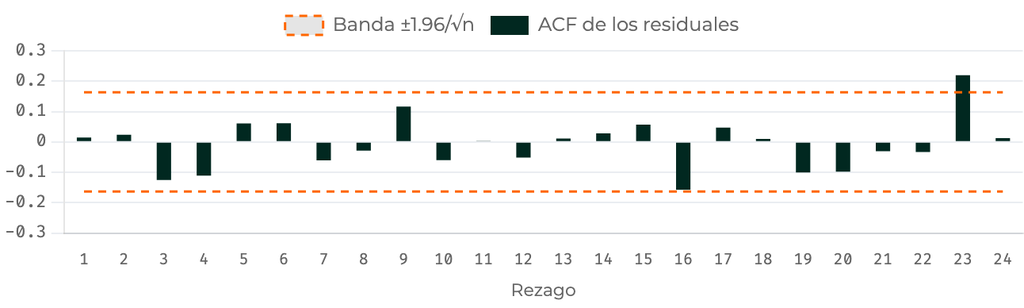

ACF de los residuales del *airline* hasta el rezago 24 (simulador del Módulo 6)

`Dato` El 3 queda en −0.125, el 9 en 0.117 y el 16 en −0.157, dentro de \(\pm0.163\); **el 23 sobrevive**, en 0.220. `Interpretación` Una barra aislada y sin explicación es esperable por azar: perseguirla con parámetros es lo que el capítulo desaconseja.

Contexto: residuales del *airline* sobre `AirPassengers` en logaritmos. La banda usa los 144 residuales que devuelve R; con 131 sería \(\pm0.171\), y solo el 23 seguiría fuera. Fuente: J `airline.diagnostico.acf` · R `m7`

Capítulo 5 · Modelos SARIMASeries de Tiempo · UnBosque55 / 84

Módulo 7 · Caso completo: log(AirPassengers)

## Los satélites, comprobados: el modelo predice 0.1471 y la muestra da 0.064 y 0.152

| Rezago | Teórica del modelo ajustado | Muestral |
| --- | --- | --- |
| 1 | \(\theta/(1+\theta^2)=-0.3460\) | −0.341 |
| 12 | \(\Theta/(1+\Theta^2)=-0.4251\) | −0.387 |
| 11 y 13 | \(\rho_1\rho_{12}=0.1471\) | 0.064 y 0.152 |

`Interpretación` Con \(n=131\) el error estándar ronda \(1/\sqrt n=0.087\): los dos satélites son compatibles con 0.1471. Dos parámetros explican **cuatro** autocorrelaciones: la estructura es multiplicativa.

Contexto: `AirPassengers` en logaritmos. Fuente: J `teoricas.ma1_sma1`, `combinaciones.d1_D1` · R `m4`, `m7`

Capítulo 5 · Modelos SARIMASeries de Tiempo · UnBosque56 / 84

Módulo 7 · Caso completo: log(AirPassengers)

## El exp() del pronóstico en logaritmos es la mediana, y el intervalo no es simétrico

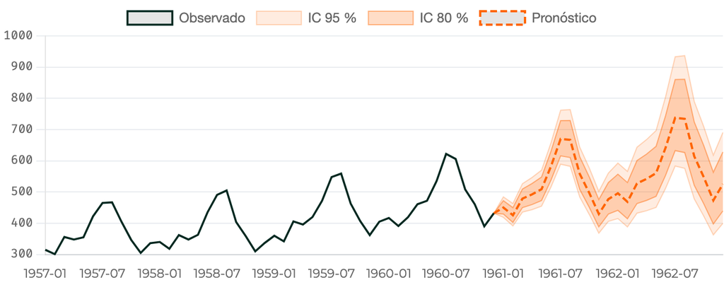

Pronóstico del *airline* a 24 meses con bandas del 80 y 95 % (simulador del Módulo 7)

`Dato` A 24 meses: **525.46** miles de pasajeros, con intervalo del 95 % de 399.66 a 690.85 (126 por debajo, 165 por encima). `Definición` Si \(\log y\sim N(\mu,\sigma^2)\), \(E[y]=e^{\mu+\sigma^2/2}>e^\mu\).

Contexto: pronóstico desde 1960-12, horizonte 1962-12. Fuente: J `pronostico.original` · R `m7.pron24`

Capítulo 5 · Modelos SARIMASeries de Tiempo · UnBosque57 / 84

Módulo 7 · Caso completo: log(AirPassengers)

## El caso completo cabe en seis líneas de R

Diagnóstico y pronóstico del airline

```
library(forecast)
ap  <- log(AirPassengers)
fit <- Arima(ap, order = c(0, 1, 1),
             seasonal = list(order = c(0, 1, 1), period = 12))
Box.test(residuals(fit), lag = 24, type = "Ljung-Box", fitdf = 2)
#> X-squared = 26.446, df = 22, p-value = 0.233
p <- forecast(fit, h = 24, level = c(80, 95))
round(unname(exp(c(p$mean[24], p$lower[24, 2], p$upper[24, 2]))), 2)
#> [1] 525.46 399.66 690.85
```

`fitdf = 2` descuenta los dos parámetros: los grados de libertad son \(24-2=22\).

Fuente: código del Módulo 7, recortado y ejecutado en R 4.6 · J `airline.diagnostico`58 / 84

Universidad El Bosque

Series de Tiempo

Capítulo 5 · Modelos SARIMA

Clase 1 · Módulo 1 · La firma de la estacionalidad

Módulo 2 · Notación SARIMA y polinomio multiplicativo

Módulo 3 · Diferenciación estacional: cuántas y en qué orden

Módulo 4 · Identificar los órdenes estacionales

Módulo 5 · El modelo airline

Clase 2 · Módulo 6 · Estimar, comparar y diagnosticar

Módulo 7 · Caso completo: log(AirPassengers)

Módulo 8 · Segundo caso y contraejemplo

Módulo 9 · Regresores de calendario y SARIMAX

Módulo 10 · Cuando \(m\) es grande: Fourier y STL

Módulo 11 · Panorama comparativo y cierre

Parte 8 de 11

08

## Módulo 8 · Segundo caso y contraejemplo

Repetir el recorrido en una serie donde las pruebas engañan, y saber descartar la estacionalidad cuando no está.

Leer en el material: Segundo caso y contraejemplo

59 / 84

Módulo 8 · Segundo caso y contraejemplo

## USAccDeaths vuelve a elegir el *airline*, con errores estándar 1.4 y 2.4 veces mayores

- `Dato` Tras decidir \(D=1\) y luego \(d=1\): \(\hat\theta=-0.4303\) (e. e. 0.1228), \(\hat\Theta=-0.5528\) (e. e. 0.1784)
- `Dato` AICc 857.32; Ljung–Box(24): \(p=0.2477\)
- `Interpretación` Con la mitad de observaciones que AirPassengers (72 frente a 144), los errores estándar son 1.4 (\(\theta\)) y 2.4 (\(\Theta\)) veces mayores, y los coeficientes, casi los mismos

Contexto: `USAccDeaths`, sin logaritmo (la amplitud no crece con el nivel). Fuente: J `usaccdeaths` · R

Capítulo 5 · Modelos SARIMASeries de Tiempo · UnBosque60 / 84

Módulo 8 · Segundo caso y contraejemplo

## La TRM es mensual y no tiene estacionalidad: cuatro comprobaciones coinciden

| Evidencia | Qué se mide | Resultado |
| --- | --- | --- |
| Prueba automática | `nsdiffs(trm)`, con `seas` y con `ocsb` | 0 y 0 |
| Correlograma | \(\hat\rho_{12}, \hat\rho_{24}, \hat\rho_{36}\) de ∇TRM, banda 0.167 | −0.002, −0.067, 0.071: **ninguno fuera** |
| Ajuste forzado | Un SAR(1)\(_{12}\) impuesto | \(\hat\Phi=0.0013\) (e. e. 0.0899), \(t=0.015\) |
| Criterio | AICc forzado frente a la caminata aleatoria, ARIMA(0,1,0) | 1708.00 frente a 1705.94: **peor** |

`Interpretación` Un precio de mercado no debería tener estación: si hubiera un mes barato predecible, el arbitraje lo borraría. La TRM mensual es un promedio, no el precio con que se negocia, pero hereda esa falta de patrón.

Contexto: TRM, ene. 2015–jun. 2026 (\(n=138\)), copia congelada. Fuente: J `trm_contraejemplo` · R

Capítulo 5 · Modelos SARIMASeries de Tiempo · UnBosque61 / 84

Universidad El Bosque

Series de Tiempo

Capítulo 5 · Modelos SARIMA

Clase 1 · Módulo 1 · La firma de la estacionalidad

Módulo 2 · Notación SARIMA y polinomio multiplicativo

Módulo 3 · Diferenciación estacional: cuántas y en qué orden

Módulo 4 · Identificar los órdenes estacionales

Módulo 5 · El modelo airline

Clase 2 · Módulo 6 · Estimar, comparar y diagnosticar

Módulo 7 · Caso completo: log(AirPassengers)

Módulo 8 · Segundo caso y contraejemplo

Módulo 9 · Regresores de calendario y SARIMAX

Módulo 10 · Cuando \(m\) es grande: Fourier y STL

Módulo 11 · Panorama comparativo y cierre

Parte 9 de 11

09

## Módulo 9 · Regresores de calendario y SARIMAX

Lo que la estacionalidad estadística no puede capturar —los efectos del calendario que se mueven de año en año— entra como regresor.

Leer en el material: Regresores de calendario y SARIMAX

62 / 84

Módulo 9 · Regresores de calendario y SARIMAX

## El SARIMA no ve lo que el calendario cambia de sitio de un año a otro

| Efecto | Por qué el SARIMA no lo ve | Regresor |
| --- | --- | --- |
| Longitud del mes | Febrero tiene 28 o 29 días; julio, 31 | \(\log\)(días del mes) |
| Fiestas móviles | La Semana Santa cae en marzo o en abril | Indicadora del mes de Pascua |
| Días hábiles | Dos meses de 31 días pueden tener 22 o 23 laborables | Número de días hábiles |
| Fiestas fijas | Caen siempre en el mismo mes | Ninguno: ya está en el término estacional |

`Definición` El SARIMA supone que el patrón se repite en la **misma posición** cada \(m\) observaciones.

Fuente: C Módulo 963 / 84

Módulo 9 · Regresores de calendario y SARIMAX

## SARIMAX es una regresión con errores SARIMA, no un SARIMA con términos añadidos

Regresión con errores SARIMA

$$y_t=\beta' x_t+\eta_t,\qquad \eta_t\sim\text{SARIMA}(p,d,q)(P,D,Q)_m$$

- `Interpretación` \(\beta\) mide el efecto del regresor **una vez descontada** la dinámica; el error estándar de un MCO ingenuo ignora la autocorrelación y suele quedarse corto
- `Definición` En statsmodels, `SARIMAX` con `exog` es este mismo modelo, igual que `Arima(…, xreg = )` en R; con \(d\) o \(D\) mayores que 0 equivale a diferenciar la serie y los regresores, y statsmodels solo lo hace así con `simple_differencing=True`

Fuente: C Módulo 9, definición64 / 84

Módulo 9 · Regresores de calendario y SARIMAX

## Los días del mes entran con \(\hat\beta=1.084\), compatible con la aritmética

| Modelo | AICc | BIC | \(\hat\beta_{\log(\text{días})}\) | \(\hat\beta_{\text{Pascua}}\) |
| --- | --- | --- | --- | --- |
| *airline* sin regresores | −483.21 | −474.77 | — | — |
| + log(días del mes) | −486.54 | −475.35 | 1.1157 (\(t=2.39\)) | — |
| + log(días) + Pascua | **−490.72** | **−476.83** | 1.0840 (\(t=2.43\)) | 0.0290 (\(t=2.60\)) |

`Dato` Pascua: 2.9 % más pasajeros en su mes; en estos 12 años cayó 2 veces en marzo y 10 en abril. `Interpretación` Si los pasajeros fueran proporcionales a los días, \(\beta\) valdría exactamente 1.

Contexto: `AirPassengers` en logaritmos; febrero frente a un mes de 31 días: 10.7 % de diferencia de duración. Fuente: J `calendario` · R `m9`

Capítulo 5 · Modelos SARIMASeries de Tiempo · UnBosque65 / 84

Pregunta para la clase

## ¿Cuánto vale el \(t\) de \(H_0:\beta=1\)?

\(\hat\beta_{\log(\text{días})}=1.0840\), con error estándar 0.4462.

\(t=0.188\) · no se rechaza

\(t=(1.0840-1)/0.4462=0.188\): **no se rechaza** \(\beta=1\). El coeficiente es significativo y compatible con lo que predice la aritmética, aunque con mucha incertidumbre: el intervalo del 95 % va de 0.21 a 1.96.

Fuente: C autoevaluación, pregunta 7 · J `calendario.modelos` · R `m9.t_beta1`66 / 84

Módulo 9 · Regresores de calendario y SARIMAX

## Ganar 7.5 puntos de AICc no es pronosticar mejor

- `Dato` El *airline* con calendario mejora el AICc en 7.5 puntos
- `Dato` Fuera de muestra, en los últimos 24 meses, pronostica **peor**: RMSE 45.48 frente a 43.18
- `Interpretación` El AICc mide ajuste penalizado **dentro** de la muestra; dos parámetros más estimados sobre 131 observaciones también añaden varianza

Contexto: `AirPassengers`; entrenamiento hasta 1958-12. Fuente: J `calendario.modelos`, `comparativa` · R

Capítulo 5 · Modelos SARIMASeries de Tiempo · UnBosque67 / 84

Universidad El Bosque

Series de Tiempo

Capítulo 5 · Modelos SARIMA

Clase 1 · Módulo 1 · La firma de la estacionalidad

Módulo 2 · Notación SARIMA y polinomio multiplicativo

Módulo 3 · Diferenciación estacional: cuántas y en qué orden

Módulo 4 · Identificar los órdenes estacionales

Módulo 5 · El modelo airline

Clase 2 · Módulo 6 · Estimar, comparar y diagnosticar

Módulo 7 · Caso completo: log(AirPassengers)

Módulo 8 · Segundo caso y contraejemplo

Módulo 9 · Regresores de calendario y SARIMAX

Módulo 10 · Cuando \(m\) es grande: Fourier y STL

Módulo 11 · Panorama comparativo y cierre

Parte 10 de 11

10

## Módulo 10 · Cuando \(m\) es grande: Fourier y STL

Todo lo anterior descansa en que \(m=12\) sea pequeño.

Leer en el material: Cuando m es grande: Fourier y STL

68 / 84

Módulo 10 · Cuando \(m\) es grande: Fourier y STL

## Con \(m\) grande el SARIMA falla por tres motivos

| Problema | \(m=12\) | \(m=52\) | \(m=365\) |
| --- | --- | --- | --- |
| Observaciones que cuesta \(\nabla_m\) | 12 | 52 | 365 |
| Rezago que alcanza un solo \(\Theta\) | 12 | 52 | 365 |
| Términos de Fourier con \(K=3\) | 6 | 6 | 6 |

- `Dato` Tres años semanales (\(n=156\)): \(\nabla_{52}\) deja 104 observaciones
- `Dato` Con frecuencia 365, `auto.arima` elige ARIMA(0,0,0)(0,1,0)\(_{365}\): gasta 365 de 800 observaciones y no prueba ningún \(\Phi\) ni \(\Theta\): los limita a \(\lfloor n/(3m)\rfloor=0\)
- `Definición` Y con datos diarios el periodo anual es 365.25: no es un número entero de rezagos

Contexto: series simuladas (semilla 1); la de frecuencia 365, un seno anual más ruido. Fuente: J `fourier.costo_m` · R `m10`

Capítulo 5 · Modelos SARIMASeries de Tiempo · UnBosque69 / 84

Módulo 10 · Cuando \(m\) es grande: Fourier y STL

## Fourier modela la estación con \(2K\) parámetros, sea cual sea \(m\)

Regresión armónica

$$y_t=\beta_0+\sum_{k=1}^{K}\Big[\alpha_k\sin\tfrac{2\pi kt}{m}+\delta_k\cos\tfrac{2\pi kt}{m}\Big]+\eta_t$$

- `Definición` \(\eta_t\) es un ARIMA **no** estacional; \(K\) controla la suavidad
- `Definición` Con \(K=m/2\), los términos equivalen a \(m-1\) indicadoras mensuales: once con \(m=12\)

Fuente: C Módulo 10, definición70 / 84

Módulo 10 · Cuando \(m\) es grande: Fourier y STL

## Hace falta \(K=5\) para que Ljung–Box deje de rechazar

| \(K\) | Términos | Errores | \(n\) efectivo | AICc | LB(24) \(p\) |
| --- | --- | --- | --- | --- | --- |
| 1 | 2 | ARIMA(5,1,0) | 143 | −359.18 | < 0.0001 |
| 2 | 4 | ARIMA(0,1,4) | 143 | −409.18 | < 0.0001 |
| 3 | 6 | ARIMA(2,1,2) | 143 | −460.96 | < 0.0001 |
| 4 | 8 | ARIMA(1,1,4) | 143 | −495.24 | 0.0001 |
| 5 | 10 | ARIMA(0,1,4) | 143 | −521.22 | 0.1341 |
| 6 | 11 | ARIMA(0,1,4) | 143 | **−521.45** | 0.1100 |

Contexto: `AirPassengers` en logaritmos, todos con \(D=0\). Fuente: J `fourier.resultados`

Capítulo 5 · Modelos SARIMASeries de Tiempo · UnBosque71 / 84

Pregunta para la clase

## Regresión armónica con AICc −521.2 y *airline* con −483.2: ¿cuál eliges?

Misma serie mensual. La armónica tiene \(D=0\); el *airline*, \(D=1\).

1. La armónica: gana por 38 puntos
2. Ninguno con esa información
3. El *airline*: 2 parámetros frente a 15
4. La armónica: su Ljung–Box no rechaza

2 · Ninguno con esa información

Los AICc se calculan sobre 143 y 131 observaciones: no están en la misma escala. Entre familias, **solo fuera de muestra**. (Los dos pasan Ljung–Box: 0.1341 y 0.2330, así que eso tampoco desempata.)

Contexto: `AirPassengers` en logaritmos. Fuente: J `fourier`, `airline` · C autoevaluación, pregunta 6

Capítulo 5 · Modelos SARIMASeries de Tiempo · UnBosque72 / 84

Módulo 10 · Cuando \(m\) es grande: Fourier y STL

## SARIMA, Fourier o STL: depende de \(m\) y de cómo cambia el patrón

### SARIMA

\(m\) pequeño y un patrón que **evoluciona** despacio.

### Fourier

\(m\) grande, o varias estacionalidades a la vez (día de la semana **y** día del año).

### STL + ARIMA

La descomposición del capítulo 1 más un ARIMA: series largas donde el patrón cambia de forma; supone que la estacionalidad no interactúa con la dinámica.

`Opinión` El argumento de Fourier es para cuando el SARIMA no cabe, no para cuando cabe.

Contexto: sobre `AirPassengers` en logaritmos, STL + ARIMA da errores ARIMA(1,1,1) con deriva. Fuente: C Módulo 10 · J `fourier.stl`

Capítulo 5 · Modelos SARIMASeries de Tiempo · UnBosque73 / 84

Universidad El Bosque

Series de Tiempo

Capítulo 5 · Modelos SARIMA

Clase 1 · Módulo 1 · La firma de la estacionalidad

Módulo 2 · Notación SARIMA y polinomio multiplicativo

Módulo 3 · Diferenciación estacional: cuántas y en qué orden

Módulo 4 · Identificar los órdenes estacionales

Módulo 5 · El modelo airline

Clase 2 · Módulo 6 · Estimar, comparar y diagnosticar

Módulo 7 · Caso completo: log(AirPassengers)

Módulo 8 · Segundo caso y contraejemplo

Módulo 9 · Regresores de calendario y SARIMAX

Módulo 10 · Cuando \(m\) es grande: Fourier y STL

Módulo 11 · Panorama comparativo y cierre

Parte 11 de 11

11

## Módulo 11 · Panorama comparativo y cierre

Todo el capítulo ha usado criterios dentro de la muestra.

Leer en el material: Panorama comparativo y cierre

74 / 84

Módulo 11 · Panorama comparativo y cierre

## Antes de comparar: qué hace cada rival y cómo se mide el error

| Método | Qué hace |
| --- | --- |
| **ETS**(M,A,M) | Suavizamiento exponencial (Holt–Winters): error **M**ultiplicativo, tendencia **A**ditiva y estacionalidad **M**ultiplicativa. Con A\(_d\), la tendencia se amortigua |
| **Regresión armónica** | Senos y cosenos (Módulo 10) con errores ARIMA |
| **STL + ARIMA** | Quita la estacionalidad con STL (capítulo 1) y modela el resto con un ARIMA |
| *Naïve* estacional | Repite, mes a mes, el último año observado |

`Definición` Con \(e_t=y_t-\hat y_t\) en la escala original: RMSE \(=\sqrt{\overline{e_t^2}}\), MAE \(=\overline{\lvert e_t\rvert}\) y MAPE \(=100\cdot\overline{\lvert e_t/y_t\rvert}\).

Fuente: D `?ets`, `?snaive` · C Módulos 10 y 11. El ETS no ha salido antes en el curso; el capítulo 6 vuelve sobre él.75 / 84

Pregunta para la clase

## Con los últimos 24 meses como prueba, ¿qué método gana?

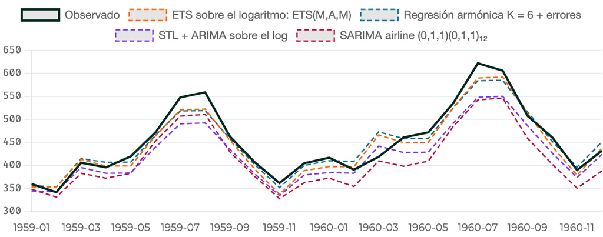

Depende de la métrica, y el SARIMA queda cuarto

RMSE: ETS sobre el logaritmo (19.43); MAE y MAPE: la regresión armónica (14.69 y 3.15 %). El *airline*: 43.18.

Contexto: `AirPassengers`, entrenamiento hasta 1958-12 (120 meses), prueba de 24. Fuente: J `comparativa`

Capítulo 5 · Modelos SARIMASeries de Tiempo · UnBosque76 / 84

Módulo 11 · Panorama comparativo y cierre

## Con una sola partición, el modelo de todo el capítulo queda cuarto

| Método | Escala | \(k\) | RMSE | MAE | MAPE % |
| --- | --- | --- | --- | --- | --- |
| ETS(M,A,M) sobre el logaritmo | log | 16 | **19.43** | 16.12 | 3.55 |
| Regresión armónica \(K=6\) + ARIMA | log | 16 | 19.51 | **14.69** | **3.15** |
| STL + ARIMA | log | 2 + 11 | 35.48 | 30.29 | 6.33 |
| **SARIMA *airline*** (y `auto.arima`) | log | 2 | 43.18 | 39.45 | 8.52 |
| *Airline* + calendario | log | 4 | 45.48 | 41.45 | 8.95 |
| ETS(M,A\(_d\),M) sobre la serie cruda | original | 17 | 72.55 | 63.21 | 13.30 |
| *Naïve* estacional | original | 0 | 76.99 | 71.25 | 15.52 |

Contexto: métricas en la escala original, la única en que son comparables. Fuente: J `comparativa.modelos`

Capítulo 5 · Modelos SARIMASeries de Tiempo · UnBosque77 / 84

Módulo 11 · Panorama comparativo y cierre

## Con 61 orígenes, el SARIMA pasa de cuarto a primero

| Método | RMSE medio (61 orígenes) | % de orígenes en que le gana al SARIMA |
| --- | --- | --- |
| **SARIMA *airline*** | **16.81** | — |
| ETS sobre el logaritmo | 21.42 | 8.2 % |
| STL + ARIMA | 21.85 | 8.2 % |
| Regresión armónica \(K=6\) | 22.38 | 9.8 % |
| ETS sobre la serie cruda | 26.38 | 14.8 % |
| *Naïve* estacional | 41.24 | 11.5 % |

`Dato` Con un corte que avanza mes a mes desde 1954-12 y el error de los 12 meses siguientes, el SARIMA le gana a cada rival en **más del 85 %** de los orígenes.

Contexto: `AirPassengers`; seis métodos distintos (el calendario queda fuera). Fuente: J `comparativa.origen_movil` · R `m11.om12`

Capítulo 5 · Modelos SARIMASeries de Tiempo · UnBosque78 / 84

Módulo 11 · Panorama comparativo y cierre

## La partición cayó justo después de la desaceleración de 1958, y el *airline* la extrapoló

- `Dato` Crecimiento del total anual en 1958: **3.4 %**; en los demás años, entre 6.2 y 21.8 %
- `Dato` El *airline* pronostica 4.7 % para 1959 y 6.9 % para 1960; lo observado fue 12.4 y 11.2 %
- `Dato` Sesgo medio 39.45 = MAE: los 24 pronósticos quedan **por debajo**
- `Dato` De los 14 orígenes en que el SARIMA no es el mejor de los seis, 12 caen entre 1957-05 y 1959-01
- `Interpretación` El problema es de **tendencia**, no de estacionalidad

Contexto: `AirPassengers`, totales anuales. Fuente: R `m11` (crecimiento del total anual, en %) · J `comparativa`

Capítulo 5 · Modelos SARIMASeries de Tiempo · UnBosque79 / 84

Módulo 11 · Panorama comparativo y cierre

## A 24 meses, SARIMA y ETS sobre el logaritmo son indistinguibles

- `Dato` Con ese horizonte caben **49** orígenes. RMSE medio: SARIMA 26.00, ETS sobre el logaritmo 26.61, STL 27.80, armónica 28.30
- `Dato` El ETS sobre el logaritmo le gana al SARIMA en el **49.0 %** de los orígenes
- `Dato` Con solo el error del mes 12, el SARIMA vuelve a quedar **cuarto**: 18.22 frente a 15.96 del ETS sobre el logaritmo

Contexto: `AirPassengers`; mismo origen móvil, horizonte 24. Error del mes 12: media de \(\lvert e_{12}\rvert\) sobre 61 orígenes. Fuente: R `m11.om24`, `m11.om12` · C Módulo 11

Capítulo 5 · Modelos SARIMASeries de Tiempo · UnBosque80 / 84

Opinión

## Una sola partición no decide nada: horizonte y métrica se fijan antes de mirar

Lo que acaba de pasar —una conclusión que se invierte al cambiar la partición— es el problema que resuelve el capítulo 6: origen móvil, cobertura de los intervalos y métricas comparables.

Capítulo 5 · Modelos SARIMASeries de Tiempo · UnBosque81 / 84

Módulo 11 · Panorama comparativo y cierre

## El SARIMA frente a lo que se usa hoy: cuándo, no cuál es mejor

| Método | Dónde brilla | Dónde falla |
| --- | --- | --- |
| **SARIMA** | \(n\) de decenas a cientos; intervalos con base teórica | \(m\) grande o múltiple; quiebres |
| **ETS** | Robusto, automático; estación multiplicativa | Sin regresores |
| **Regresión armónica** | \(m\) grande o varias estacionalidades | El patrón no cambia con los años |
| **Prophet** | Series de negocio largas, con festivos | Intervalos mal calibrados |
| **RNN / LSTM** | Miles de series relacionadas | Con 144 puntos no hay con qué entrenar |
| **Transformers** | Horizontes largos, muchas covariables | Cómputo; pierden en series cortas |

`Opinión` [SIN VERIFICAR] Resumen del capítulo de las competencias de pronóstico M4 y M5, sin cifras ni citas concretas.

Fuente: C Módulo 11, «SARIMA frente a lo que se usa hoy»82 / 84

Módulo 11 · Panorama comparativo y cierre

## Lo que se llevan del capítulo

- La parte estacional **multiplica**: satélites en \(m\pm1\) sin parámetros nuevos
- Primero \(D\), después \(d\); y el AICc **no** se compara entre distintos \(D\)
- El *airline* es el punto de partida; el diagnóstico (Ljung–Box con \(2m\)) lo certifica
- Calendario y fiestas móviles van como **regresores**; con \(m\) grande, Fourier o STL
- Una sola partición no decide nada: eso lo resuelve el capítulo 6

Javier Mauricio Sierra

Capítulo 5 · Modelos SARIMASeries de Tiempo · UnBosque83 / 84

Módulo 11 · Panorama comparativo y cierre

## Para seguir: tres ejercicios y las lecturas

### Ejercicios propuestos (Módulo 11)

1. **co2**: recorre el ciclo y explica qué le pasa al AICc del modelo sin \(D\)
2. **USAccDeaths** por los dos caminos: ¿misma serie?, ¿mismo modelo?
3. **TRM** con tres evidencias, y la armónica de co2 frente al *airline*: ¿se pueden comparar?

### Lecturas

- FPP3, §9.9 (SARIMA) y §12.1 (estacionalidad compleja)
- FPP3, §7.4 (predictores de calendario) y §10.5 (regresión armónica dinámica)
- Shumway y Stoffer, cap. 3.9 [SIN VERIFICAR]
- Box, Jenkins, Reinsel y Ljung, cap. 9 [SIN VERIFICAR]

Secciones de FPP3 comprobadas en otexts.com/fpp3 (2026-10-27). Fuente: C Módulo 11, «Ejercicios propuestos» y «Lecturas». Informe de verificación: `fuentes/verificacion/verificacion_cifras_cap5.md`

Capítulo 5 · Modelos SARIMASeries de Tiempo · UnBosque84 / 84

·

00:00

A continuación

Notas